# Relatório Parcial - Maratona de Filmes

- Matéria: Supercomputação
- Aluno: Guilherme Lunetta

## O problema

O objetivo deste relatório é apresentar a solução para o desafio de selecionar o maior número possível de filmes para serem assistidos em um dia, levando em consideração as restrições de horários disponíveis e o número máximo de filmes permitidos em cada categoria.

A entrada consiste em um inteiro N, representando o número de filmes disponíveis, e N trios de inteiros (H[i], F[i], C[i]), representando a hora de início, a hora de fim e a categoria do i-ésimo filme. Além disso, há um inteiro M, representando o número de categorias, e uma lista de M inteiros representando o número máximo de filmes que podem ser assistidos em cada categoria. A saída esperada é um inteiro representando o número máximo de filmes que podem ser assistidos de acordo com as restrições de horários e número máximo por categoria, a porcentagem de tempo de tela e os filmes escolhidos.

Além disso, devemos desenvolver duas soluções distintas, uma solução usando uma heurística gulosa e a outra usando a mesma heurística gulosa porém com uma aleatorização, buscando novas soluções.

**Exemplo de arquivo de entrada:**

```
10 4
1 3 1 2
11 13 3
14 15 3
10 16 2
10 14 1
11 17 2
11 14 3
13 15 3
14 15 1
12 16 4
12 13 4
```

**Exemplo de arquivo de saída:**

[output not shown]

## Implementação

A implementação foi feita da seguinte forma:

- **1)** Leitura do arquivo de entrada e armazenamento em vetores, estruturas customizadas, constantes e variáveis.
- **2)** Ordenar os filmes por hora de término, do menor para o maior. Caso os horários de término sejam iguais, ordenamos por hora de início, da menor para a maior.
- **3)** Escolher os filmes que serão assistidos, seguindo a regra de que um filme não pode começar ou terminar durante a exibição de outro filme já escolhido e a regra de que um filme não pode ser escolhido se o máximo de filmes de sua categoria já foi atingido.
  - 3.1) Também foram ignorados os filmes que começam e terminam no mesmo horário, visto que é impossível assistir um filme assim.
  - 3.2) Por fim, foram ignorados filmes que começam depois de terminar (confuso, né?) pois isso é impossível sem uma máquina do tempo.
- **4)** Na heurística gulosa, escolhe-se o filme que termina mais cedo, desde que respeite a regra da categoria e a regra de exibição. Na heurística gulosa aleatorizada, existe uma chance de 25% onde escolhe-se um filme aleatório da lista de filmes, desde que respeito a regra da categoria e da exibição e os outros 75% de chance, segue a heurística gulosa padrão.
- **5)** Escrever o arquivo de saída contendo o número de filmes escolhidos, a porcentagem de tempo de tela e a lista de filmes escolhidos com suas informações, em ordem.

## Heurística Gulosa

Os filmes foram transformados em uma estrutura de dados com as suas informações:

```
struct movie {
    int index;
    int start;
    int end;
    int category;
};
```

Para saber quais horários do dia ainda estavam disponíves a fim de escolher se um filme será assistido ou não, foi necessário usar uma estrutura de dados chamada **bitset**. No entanto, foi desenvolvida uma estrutura **bitset** customizada para o problema, diferente da disponível na biblioteca **bitset** do C++. Segue o código abaixo:

```
struct rbitset {
    int size = 24;
    vector<int> bs = vector<int>(24, 0);

    int get(int index) {
        return bs[index];
    }

    void set(int index) {
        bs[index] = 1;
    }

    void print() {
        for (int i = 0; i < size; i++) {
            cout << bs[i];
        }

        cout << endl;
    }
};
```

Como dito anteriormente, a função que ordena os filmes por hora de término, da menor para a maior também os ordena por hora de início, da menor para a maior, caso existam filmes em que a hora de término seja a mesma, melhorando ainda mais as escolhas. Segue o código abaixo da função:

```
bool orderByEndTime(movie &a, movie &b) {
    if (a.end != b.end) {
        return a.end < b.end;
    }

    return a.start < b.start;
}
```

Seguindo nosso algoritmo, chegamos na parte de escolher os filmes, isso foi feito em duas partes, a primeira é uma função que diz se o filme é elegível para assistir seguindo as regras mencionadas anteriormente. E a segunda é o loop principal do algoritmo que preenche o vetor de filmes escolhidos e atualiza o vetor de filmes por categoria caso o filme seja elegível. Segue a função e o loop principal abaixo:

```
bool isWatchable(int start, int end, rbitset &bitset) {
    if (start == end) {
        return false;
    }

    if (start > end) {
        return false;
    }

    for (int i = start; i < end; i++) {
        if (bitset.get(i)) {
            return false;
        }
    }

    return true;
}

for (int i = 0; i < numMovies; i++) {
    if (categories[movies[i].category] != 0) {
        if (isWatchable(movies[i].start, movies[i].end, bitset)) {
            populateBiset(movies[i].start, movies[i].end, bitset);
            chosenMovies.push_back(movies[i]);
            categories[movies[i].category]--;
        }
    }
}
```

Lembrando que a função **populateBitset()** apenas atualiza o bitset com os horários do novo filme para que não ocorra nenhum equívoco na escolha dos próximos filmes.

Por fim, a função de escrita do arquivo de output que, como dito anteriormente, cria um arquivo e coloca as informações importantes, sendo elas: número de filmes escolhidos, porcentagem de tempo de tela e os filmes escolhidos em ordem. Segue o código abaixo:

```
void writeOutput(string filename, vector<movie> movies) {
    int numMovies = movies.size();

    int hoursWithoutMovies = 0;
    for (int i = 0; i < movies.size()-1; i++) {
        hoursWithoutMovies += movies[i+1].start - movies[i].end;
    }

    if (movies[numMovies-1].end != 24) {
        hoursWithoutMovies += 24 - movies[numMovies-1].end;
    }

    if (movies[0].start != 0) {
        hoursWithoutMovies += movies[0].start;
    }

    double screenPercentage = ((24 - hoursWithoutMovies) * 100) / 24.0;

    fs::path dir_path("outputs/");
    if (!fs::exists(dir_path)) {
        fs::create_directory(dir_path);
    }

    ofstream inputFile;
    filename = filename.replace(0, 5, "outputs/output-gulosa");
    inputFile.open(filename);
    inputFile << numMovies << endl;
    inputFile << screenPercentage << endl;

    for (int i = 0; i < movies.size(); i++) {
        inputFile << movies[i].index << " " << movies[i].start << " " << movies[i].end << " " << movies[i].category << endl;
    }

    inputFile.close();
}
```

## Heurística Gulosa Aleatória

Na heurística gulosa aleatorizada, a única diferença é no loop principal do algoritmo, onde antes de checarmos se um filme é elegível ou não, checamos se esse é um caso dos 25% de chance de escolher um filme aleatório, se sim, fazemos as mesmas checagens que a heurística gulosa padrão e continuamos. Segue o código novo abaixo:

```
for (int i = 0; i < numMovies; i++) {
    if (shouldChoose(0.25, dgenerator, ddistribution)) {
        int idx = randomInt(igenerator, idistribution);
        if (categories[movies[idx].category] != 0) {
            if (isWatchable(movies[idx].start, movies[idx].end, bitset)) {
                populateBiset(movies[idx].start, movies[idx].end, bitset);
                chosenMovies.push_back(movies[idx]);
                categories[movies[idx].category]--;
            }
        }
    } else {
        if (categories[movies[i].category] != 0) {
            if (isWatchable(movies[i].start, movies[i].end, bitset)) {
                populateBiset(movies[i].start, movies[i].end, bitset);
                chosenMovies.push_back(movies[i]);
                categories[movies[i].category]--;
            }
        }
    }
}
```

Também temos a função que nos diz se devemos escolher um filme aleatório ou não baseado na chance de 25% citada anteriormente. Segue o código abaixo:

```
bool shouldChoose(double prob, default_random_engine &eng, uniform_real_distribution<double> &dist) {
    if (dist(eng) <= prob) {
        return true;
    }

    return false;
}
```

## Profiling

Utilizando o *valgrind*, iremos analisar o comportamento de cada algoritmo, buscando entender onde o algoritmo tem mais chamadas e pode ser otimizado. Ambas análises foram feitas utilizando o input com 100000 filmes e 20 categorias.

### Profiling do algoritmo guloso

No algoritmo guloso, 57,86% das chamadas do algoritmo estão no loop de leitura dos filmes do arquivo de input e 37,04% das chamadas estão na função **sort()** de ordenação, como mostra a imagem abaixo.

OBS: Não coloquei o resultado inteiro do valgrind pois este tem aproximadamente 6 mil linhas.

[figure not shown]

### Profiling do algoritmo guloso aleatório

Assim como no algoritmo guloso, 54,55% das chamadas do algoritmo estão no loop de leitura dos filmes do arquivo de input e 34,82% das chamadas estão na função **sort()** de ordenação, como mostra a imagem abaixo.

[figure not shown]

### Conclusão do profiling

Conclui-se que o loop de leitura dos filmes e a função **sort()** são os lugares do código que necessitam de atenção quanto ao desempenho e podem ser alvos de pesquisa para otimização.

## Comparação entre as heurísticas

Vamos comparar os resultados de cada heurística. Vamos comparar o número de filmes escolhidos, o tempo de execução de cada algoritmo variando os inputs e a porcentagem de tempo de tela. Os resultados serão mostrados por tabelas e gráficos.

### Número de filmes escolhidos

```python
# Importando todas as bibliotecas necessárias

import pandas as pd
import matplotlib.pyplot as plt
```

```python
# Abrindo arquivo csv em um DataFrame do pandas

df = pd.read_csv("summary.csv")
df.head(10)
```

|  | heuristic | nFilmes | nCategorias | tGulosa | tAleatoria | ncFilmes | screenTime |
| --- | --- | --- | --- | --- | --- | --- | --- |
| 0 | aleatoria | 1000 | 10 | 0.114160 | 0.114677 | 10 | 79.1667 |
| 1 | aleatoria | 100000 | 20 | 0.180130 | 0.184844 | 8 | 79.1667 |
| 2 | aleatoria | 10 | 20 | 0.112263 | 0.112975 | 5 | 58.3333 |
| 3 | aleatoria | 10 | 2 | 0.114069 | 0.112814 | 2 | 20.8333 |
| 4 | gulosa | 10000000 | 2 | 6.808819 | 7.501597 | 4 | 16.6667 |
| 5 | gulosa | 10 | 5 | 0.113482 | 0.113138 | 5 | 41.6667 |
| 6 | gulosa | 10 | 10 | 0.112667 | 0.112782 | 4 | 54.1667 |
| 7 | gulosa | 10000000 | 5 | 6.987567 | 7.773860 | 14 | 58.3333 |
| 8 | aleatoria | 10 | 5 | 0.113482 | 0.113138 | 5 | 41.6667 |
| 9 | gulosa | 100 | 5 | 0.113765 | 0.112831 | 12 | 83.3333 |

```python
# Código para analise do número de filmes escolhidos

df_nFilmes = df[["heuristic", "nFilmes", "nCategorias","ncFilmes"]]
df_nFilmes = df_nFilmes.sort_values(["nFilmes", "nCategorias"])
df_nFilmes.head(10)
```

|  | heuristic | nFilmes | nCategorias | ncFilmes |
| --- | --- | --- | --- | --- |
| 3 | aleatoria | 10 | 2 | 2 |
| 37 | gulosa | 10 | 2 | 2 |
| 5 | gulosa | 10 | 5 | 5 |
| 8 | aleatoria | 10 | 5 | 5 |
| 6 | gulosa | 10 | 10 | 4 |
| 25 | aleatoria | 10 | 10 | 3 |
| 2 | aleatoria | 10 | 20 | 5 |
| 49 | gulosa | 10 | 20 | 5 |
| 17 | gulosa | 10 | 100 | 4 |
| 19 | aleatoria | 10 | 100 | 4 |

```python
pivot_table = df_nFilmes.pivot(index=["nFilmes", "nCategorias"], columns="heuristic", values="ncFilmes")
pivot_table = pivot_table.rename(columns={"aleatoria": "ncFilmes_aleatoria", "gulosa": "ncFilmes_gulosa"})
pivot_table
```

| nFilmes | heuristic nCategorias | ncFilmes_aleatoria | ncFilmes_gulosa |
| --- | --- | --- | --- |
| 10 | 2 | 2 | 2 |
|  | 5 | 5 | 5 |
|  | 10 | 3 | 4 |
|  | 20 | 5 | 5 |
|  | 100 | 4 | 4 |
| 100 | 2 | 4 | 4 |
|  | 5 | 6 | 12 |
|  | 10 | 5 | 12 |
|  | 20 | 9 | 13 |
|  | 100 | 7 | 11 |
| 1000 | 2 | 3 | 3 |
|  | 5 | 9 | 11 |
|  | 10 | 10 | 22 |
|  | 20 | 7 | 22 |
|  | 100 | 9 | 22 |
| 100000 | 2 | 3 | 3 |
|  | 5 | 10 | 16 |
|  | 10 | 10 | 24 |
|  | 20 | 8 | 24 |
|  | 100 | 7 | 24 |
| 10000000 | 2 | 4 | 4 |
|  | 5 | 8 | 14 |
|  | 10 | 8 | 24 |
|  | 20 | 9 | 24 |
|  | 100 | 9 | 24 |

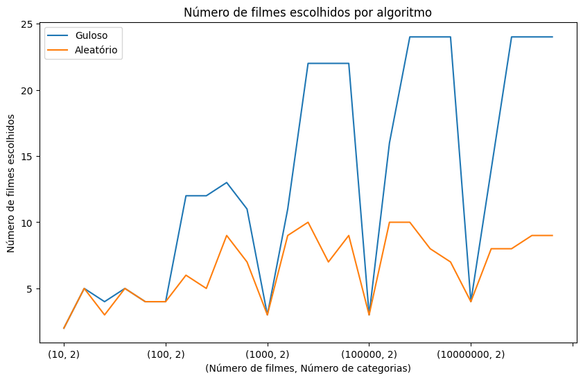

```python
fig, ax = plt.subplots(figsize=(10, 6))

pivot_table["ncFilmes_gulosa"].plot(ax=ax, label="Guloso")
pivot_table["ncFilmes_aleatoria"].plot(ax=ax, label="Aleatório")
ax.set_title("Número de filmes escolhidos por algoritmo")
ax.set_xlabel("(Número de filmes, Número de categorias)")
ax.set_ylabel("Número de filmes escolhidos")
ax.legend()

plt.show()
```

### Tempo de execução

```python
# Código para analisar tempo de execução entre algoritmos

df_tempo = df[["nFilmes", "nCategorias","tGulosa", "tAleatoria"]]
df_tempo = df_tempo.sort_values(["nFilmes", "nCategorias"])
df_tempo.head(10)
```

|  | nFilmes | nCategorias | tGulosa | tAleatoria |
| --- | --- | --- | --- | --- |
| 3 | 10 | 2 | 0.114069 | 0.112814 |
| 37 | 10 | 2 | 0.114069 | 0.112814 |
| 5 | 10 | 5 | 0.113482 | 0.113138 |
| 8 | 10 | 5 | 0.113482 | 0.113138 |
| 6 | 10 | 10 | 0.112667 | 0.112782 |
| 25 | 10 | 10 | 0.112667 | 0.112782 |
| 2 | 10 | 20 | 0.112263 | 0.112975 |
| 49 | 10 | 20 | 0.112263 | 0.112975 |
| 17 | 10 | 100 | 0.112090 | 0.112615 |
| 19 | 10 | 100 | 0.112090 | 0.112615 |

```python
df_tempo = df_tempo.set_index(["nFilmes", "nCategorias"])
df_tempo = df_tempo.drop_duplicates()
df_tempo.head(10)
```

| nFilmes | nCategorias | tGulosa | tAleatoria |
| --- | --- | --- | --- |
| 10 | 2 | 0.114069 | 0.112814 |
|  | 5 | 0.113482 | 0.113138 |
|  | 10 | 0.112667 | 0.112782 |
|  | 20 | 0.112263 | 0.112975 |
|  | 100 | 0.112090 | 0.112615 |
| 100 | 2 | 0.113420 | 0.113404 |
|  | 5 | 0.113765 | 0.112831 |
|  | 10 | 0.113128 | 0.112041 |
|  | 20 | 0.112759 | 0.110083 |
|  | 100 | 0.113603 | 0.113253 |

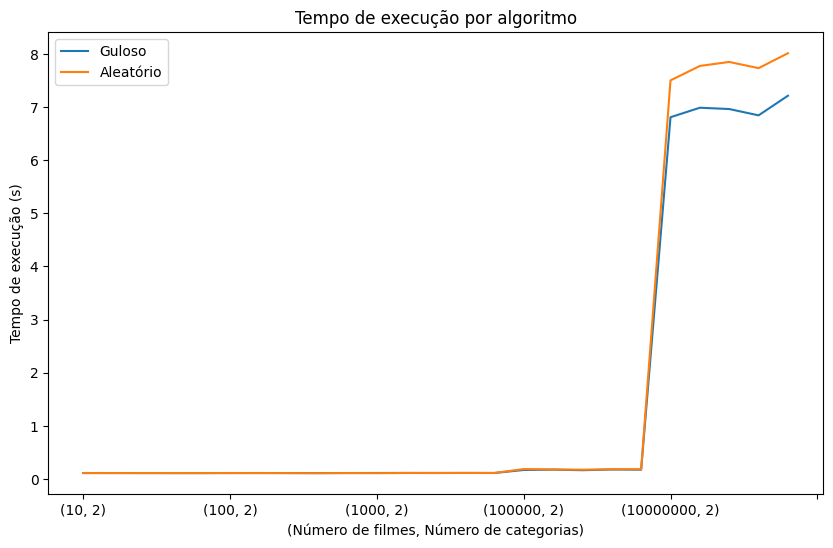

```python
fig, ax = plt.subplots(figsize=(10, 6))

df_tempo["tGulosa"].plot(ax=ax, label="Guloso")
df_tempo["tAleatoria"].plot(ax=ax, label="Aleatório")
ax.set_title("Tempo de execução por algoritmo")
ax.set_xlabel("(Número de filmes, Número de categorias)")
ax.set_ylabel("Tempo de execução (s)")
ax.legend()

plt.show()
```

### Porcentagem de tempo de tela

```python
df_screen = df[["heuristic", "nFilmes", "nCategorias","screenTime"]]
df_screen = df_screen.sort_values(["nFilmes", "nCategorias"])
df_screen.head(10)
```

|  | heuristic | nFilmes | nCategorias | screenTime |
| --- | --- | --- | --- | --- |
| 3 | aleatoria | 10 | 2 | 20.8333 |
| 37 | gulosa | 10 | 2 | 25.0000 |
| 5 | gulosa | 10 | 5 | 41.6667 |
| 8 | aleatoria | 10 | 5 | 41.6667 |
| 6 | gulosa | 10 | 10 | 54.1667 |
| 25 | aleatoria | 10 | 10 | 45.8333 |
| 2 | aleatoria | 10 | 20 | 58.3333 |
| 49 | gulosa | 10 | 20 | 58.3333 |
| 17 | gulosa | 10 | 100 | 37.5000 |
| 19 | aleatoria | 10 | 100 | 37.5000 |

```python
pivot_table = df_screen.pivot(index=["nFilmes", "nCategorias"], columns="heuristic", values="screenTime")
pivot_table = pivot_table.rename(columns={"aleatoria": "stAleatoria", "gulosa": "stGulosa"})
pivot_table
```

| nFilmes | heuristic nCategorias | stAleatoria | stGulosa |
| --- | --- | --- | --- |
| 10 | 2 | 20.8333 | 25.0000 |
|  | 5 | 41.6667 | 41.6667 |
|  | 10 | 45.8333 | 54.1667 |
|  | 20 | 58.3333 | 58.3333 |
|  | 100 | 37.5000 | 37.5000 |
| 100 | 2 | 54.1667 | 41.6667 |
|  | 5 | 66.6667 | 83.3333 |
|  | 10 | 58.3333 | 95.8333 |
|  | 20 | 70.8333 | 95.8333 |
|  | 100 | 70.8333 | 91.6667 |
| 1000 | 2 | 25.0000 | 12.5000 |
|  | 5 | 70.8333 | 54.1667 |
|  | 10 | 79.1667 | 100.0000 |
|  | 20 | 75.0000 | 100.0000 |
|  | 100 | 79.1667 | 100.0000 |
| 100000 | 2 | 25.0000 | 12.5000 |
|  | 5 | 75.0000 | 66.6667 |
|  | 10 | 75.0000 | 100.0000 |
|  | 20 | 79.1667 | 100.0000 |
|  | 100 | 79.1667 | 100.0000 |
| 10000000 | 2 | 54.1667 | 16.6667 |
|  | 5 | 79.1667 | 58.3333 |
|  | 10 | 75.0000 | 100.0000 |
|  | 20 | 75.0000 | 100.0000 |
|  | 100 | 75.0000 | 100.0000 |

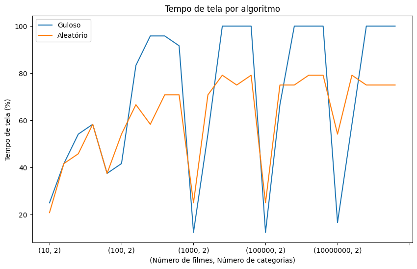

```python
fig, ax = plt.subplots(figsize=(10, 6))

pivot_table["stGulosa"].plot(ax=ax, label="Guloso")
pivot_table["stAleatoria"].plot(ax=ax, label="Aleatório")
ax.set_title("Tempo de tela por algoritmo")
ax.set_xlabel("(Número de filmes, Número de categorias)")
ax.set_ylabel("Tempo de tela (%)")
ax.legend()

plt.show()
```

## Conclusão sobre as heurísticas Gulosa e Aleatória

No quesito número de filmes escolhidos para serem assistidos, o algoritmo guloso sempre "vence" e escolhe muitos filmes, principalmente quando os arquivos de entrada são maiores. Isso era de se esperar visto que adotamos essa estratégia no algoritmo guloso de ordenar os filmes e ir selecionando eles conforme o critério de ser assistível ou não, o que faz com que muitos filmes sejam escolhidos em principalmente em arquivos de entrada grandes. Por outro lado, o algoritmo aleatório foi adotado uma estratégia de selecionar um filme assistível aleatório, fazendo com que esse filme ocupe um range de horas grande, diminuindo a quantidade de filmes escolhidos.

No quesito tempo de execução, ambos os algoritmos são muito parecidos, até com arquivos de entrada grandes, no entanto, pode-se notar uma diferença maior do que as demais no último arquivo de entrada com 10 milhões de filmes, mesmo que essa diferença não seja grotesca.

# Abordagem diferente: Busca Exaustiva

Na segunda parte do projeto, adotaremos uma abordagem bastante distinta das anteriores, conhecida como busca exaustiva.

A busca exaustiva é uma estratégia de busca que explora todas as soluções possíveis em um espaço de busca para encontrar a solução ótima. Ela examina sistematicamente todas as combinações de soluções, verificando cada uma delas em busca da solução ideal. Embora garanta a descoberta da melhor solução, pode ser computacionalmente dispendiosa em espaços de busca extensos.

## Gulosa x Aleatória x Exaustiva

Em resumo, cada uma dessas estratégias tem seus objetivos distintos:

- A busca exaustiva busca a solução ótima, examinando todas as possibilidades no espaço de busca. É adequada quando se precisa garantir a descoberta da melhor solução, embora possa ser impraticável em espaços de busca amplos.
- A busca gulosa visa encontrar uma solução aproximadamente ótima, fazendo escolhas locais ótimas em cada etapa. Essa abordagem é rápida e eficiente, mas pode levar a soluções subótimas em certos casos.
- A aleatorização visa explorar diferentes áreas do espaço de busca, descobrindo soluções potencialmente melhores do que as encontradas por uma busca determinística. A introdução de elementos aleatórios ajuda a evitar a convergência prematura para soluções subótimas, embora não garanta a descoberta da melhor solução.

Dessa forma, a escolha da estratégia adequada depende do problema em questão e das restrições de tempo e recursos disponíveis.

## Busca Exaustiva com paralelização e GPU

A busca exaustiva é uma estratégia de busca que examina todas as possíveis soluções em um espaço de busca para encontrar a melhor solução. No entanto, devido ao número exponencial de combinações a serem consideradas, a busca exaustiva pode ser computacionalmente custosa em espaços de busca grandes. Para mitigar esse problema, duas abordagens podem ser utilizadas: paralelização com OpenMP e aceleração com a GPU.

A paralelização é uma técnica que envolve dividir o trabalho em várias tarefas independentes que podem ser executadas simultaneamente em diferentes processadores ou núcleos de processamento. No contexto da busca exaustiva, isso significa dividir o espaço de busca em regiões menores e atribuir cada região a um processador ou núcleo de processamento. Dessa forma, várias regiões do espaço de busca podem ser exploradas simultaneamente, acelerando o tempo total de busca. A biblioteca OpenMP é uma ferramenta amplamente utilizada para a paralelização de código em C++ e oferece suporte a várias construções de programação paralela, como a diretiva #pragma omp parallel for. Ao utilizar o OpenMP, é possível distribuir as iterações do loop da busca exaustiva entre várias threads, permitindo uma execução paralela eficiente.

A aceleração usando a GPU (Unidade de Processamento Gráfico) é outra abordagem que visa explorar a arquitetura altamente paralela das GPUs. As GPUs são projetadas para processar grandes quantidades de dados em paralelo e podem ser extremamente eficientes em tarefas que podem ser paralelizadas. Ao utilizar a GPU para acelerar a busca exaustiva, é possível aproveitar a capacidade de processamento massivamente paralelo da GPU para explorar o espaço de busca de forma mais rápida. A biblioteca CUDA, por exemplo, permite escrever código que pode ser executado na GPU, com instruções específicas para a execução paralela em massa. Ao transferir o processamento intensivo para a GPU, é possível obter uma aceleração significativa no tempo de execução da busca exaustiva.

Ambas as abordagens, paralelização com OpenMP e aceleração usando a GPU, oferecem uma maneira de explorar o poder de processamento paralelo disponível em sistemas modernos. No entanto, a escolha entre as duas depende da natureza do problema, da disponibilidade de recursos computacionais e do conhecimento e experiência em programação paralela. A paralelização com OpenMP é uma opção mais acessível e fácil de implementar em sistemas com múltiplos núcleos de CPU. Por outro lado, a aceleração com GPU pode oferecer uma vantagem significativa em termos de desempenho para problemas altamente paralelos, desde que haja um suporte adequado de hardware e conhecimento em programação CUDA.

Em resumo, a busca exaustiva pode se beneficiar das técnicas de paralelização e aceleração usando GPU para mitigar o custo computacional em espaços de busca grandes. Essas abordagens proporcionam uma maneira de explorar o poder de processamento paralelo disponível em sistemas modernos, acelerando o tempo de execução e permitindo a busca exaustiva em problemas que seriam impraticáveis de serem resolvidos de forma determinística.

## Implementação da paralelização com OpenMP e aceleração usando GPU

Assim como na primeira abordagem do projeto usando as heurísticas gulosa e aleatória, algumas estruturas de dados e funções foram reutilizadas, sendo elas:

- Estrutura de dados para armazenar um filme
- Estrutura de dados para armazenar os horários de um dia e os respectivos filmes assistidos
- Função para ordernar os filmes por hora de início e fim
- Função para saber se um filme pode ser assistido ou não, seguindo algumas regras
- Função para escrever os resultados em um arquivo e salvá-lo no local desejado

Todos esses pontos foram reutilizados e podem ser vistos aqui: estruturas de dados e funções reutilizadas

No entanto, por se tratar de uma nova abordagem, a função principal do programa foi mudada, passanda a ser agora uma busca exaustiva. Como dito anteriormente em Abordagem diferente: busca exaustiva, a busca exaustiva examina TODAS as combinações possíveis afim de obter a melhor solução para o problema. Para isso, foi feita um função nova chamada **searchMovies** contendo a implementação da busca exaustiva.

```
vector<movie> searchMovies(vector<movie>& movies, vector<int>& categories) {
    vector<movie> bestSelection;
    int max = 0;

    // Max combinations without using pow() because it is super unefficient
    int combinations = 1 << movies.size();

    for (int mask = 0; mask < combinations; mask++) {
        vector<movie> chosenMovies;
        rbitset bitset;
        vector<int> tempCategories = categories;

        for (int i = 0; i < movies.size(); i++) {
            if (mask & (1 << i)) {
                if (tempCategories[movies[i].category] != 0 && isWatchable(movies[i].start, movies[i].end, bitset)) {
                    populateBiset(movies[i].start, movies[i].end, bitset);
                    chosenMovies.push_back(movies[i]);
                    tempCategories[movies[i].category]--;
                }
            }
        }

        if (chosenMovies.size() > max) {
            max = chosenMovies.size();
            bestSelection = chosenMovies;
        }
    }

    return bestSelection;
}
```

A função **searchMovies** recebe um vetor de filmes (vector movies) e um vetor de categorias (vector categories) como argumentos. A função retorna um vetor de filmes (vector) que representa a melhor seleção de filmes de acordo com determinados critérios.

- vector bestSelection; - Vetor que armazenará a melhor seleção de filmes.
- int max = 0; - Variável que guarda o tamanho máximo da seleção de filmes.
- int combinations = 1 << movies.size(); - Calcula o número máximo de combinações possíveis de filmes usando deslocamento de bits.

**Loop principal:**

- O loop percorre todas as combinações possíveis de filmes usando uma máscara binária (mask).
- Para cada combinação, um novo vetor chamado chosenMovies é criado para armazenar os filmes selecionados.
- Um objeto bitset e um vetor tempCategories são inicializados para rastrear as categorias assistidas e as categorias disponíveis, respectivamente.

**Loop interno:**

- O loop percorre cada filme (movies) com base no valor da máscara binária.
- Se o filme está selecionado (bit correspondente na máscara é 1), verifica se ele pode ser assistido.
- Para que um filme seja assistível, sua categoria deve estar disponível (tempCategories[movies[i].category] != 0) e deve ser possível assisti-lo com base em algum critério (não especificado no código, possivelmente definido nas funções isWatchable e populateBiset).
- Se o filme pode ser assistido, atualiza o bitset e adiciona o filme ao vetor chosenMovies. Também decrementa a contagem de categorias disponíveis.

**Atualização da melhor seleção:**

Se o tamanho da seleção atual (chosenMovies.size()) for maior que o tamanho máximo atual (max), atualiza o tamanho máximo e copia o vetor chosenMovies para bestSelection.

**Retorno do resultado:**

A função retorna o vetor bestSelection, que contém a melhor seleção de filmes encontrada. Em resumo, o código realiza uma busca exaustiva de todas as combinações possíveis de filmes, verifica se cada combinação atende a certos critérios de seleção (baseados em categorias), e retorna a melhor seleção encontrada.

### Paralelização com OpenMP

A única mudança necessária para paralelizar o código com o OpenMP (além de importar a biblioteca **omp.h**) é na função **searchMovies**.

```
vector<movie> searchMovies(vector<movie>& movies, vector<int>& categories) {
    vector<movie> bestSelection;
    int max = 0;

    // Max combinations without using pow() because it is super unefficient
    int combinations = 1 << movies.size();

    #pragma omp parallel for shared(bestSelection, max)
    for (int mask = 0; mask < combinations; mask++) {
        vector<movie> chosenMovies;
        rbitset bitset;
        vector<int> tempCategories = categories;

        for (int i = 0; i < movies.size(); i++) {
            if (mask & (1 << i)) {
                if (tempCategories[movies[i].category] != 0 && isWatchable(movies[i].start, movies[i].end, bitset)) {
                    populateBiset(movies[i].start, movies[i].end, bitset);
                    chosenMovies.push_back(movies[i]);
                    tempCategories[movies[i].category]--;
                }
            }
        }

        #pragma omp critical
        {
            if (chosenMovies.size() > max) {
                max = chosenMovies.size();
                bestSelection = chosenMovies;
            }
        }
    }

    return bestSelection;
}
```

O código apresentado é uma versão modificada da função **searchMovies**, com a adição de diretivas de OpenMP para paralelizar o loop principal do código. As diferenças entre esse código e o código anterior são:

- Adição da diretiva #pragma omp parallel for shared(bestSelection, max):

Essa diretiva indica que o loop for subsequente será executado em paralelo. A cláusula shared(bestSelection, max) especifica que as variáveis bestSelection e max serão compartilhadas entre as threads.

- Adição da diretiva #pragma omp critical:

Essa diretiva envolve a seção crítica do código, que atualiza as variáveis bestSelection e max. Garante que apenas uma thread execute essa seção de cada vez, evitando condições de corrida.

A principal diferença entre os dois códigos é a introdução do paralelismo usando as diretivas de OpenMP. Com isso, o loop principal é dividido entre várias threads, permitindo que várias combinações de filmes sejam processadas simultaneamente. O uso da cláusula **shared** garante que as threads acessem e atualizem as mesmas variáveis compartilhadas.

### Aceleração com a GPU

Já na aceleração com a GPU, o código fica bastante diferente da busca exaustiva inicial, isso porque utilizamos a biblioteca **CUDA** e a biblioteca **thrust** para mexer na GPU.

Além de importar as bibliotecas necessárias da **thrust**, várias partes do código tiveram que ser reescritar para rodar com a GPU. Segue os imports e algumas funções da exaustiva com OpenMP que tiveram que ser adaptadas para **structs**:

```
#include <thrust/device_vector.h>
#include <thrust/host_vector.h>
#include <thrust/sequence.h>
#include <thrust/sort.h>

struct rbitset {
    int size = 24;
    int bs[24];

    __host__ __device__
    rbitset() {
        for (int i = 0; i < size; i++) {
            bs[i] = 0;
        }
    }

    __host__ __device__
    int get(int index) const {
        return bs[index];
    }

    __host__ __device__
    void set(int index) {
        bs[index] = 1;
    }
};

struct orderByEndTime {
    __host__ __device__
    bool operator()(const movie& a, const movie& b) const {
        if (a.end != b.end) {
            return a.end < b.end;
        }
        return a.start < b.start;
    }
};

struct populateBitset {
    __host__ __device__
    void operator()(int start, int end, rbitset& bitset) {
        if (start == 0) {
            for (int i = start; i < end; i++) {
                bitset.set(i);
            }
        } else {
            for (int i = start - 1; i < end; i++) {
                bitset.set(i);
            }
        }
    }
};

struct isWatchable {
    __host__ __device__
    bool operator()(int start, int end, const rbitset& bitset) const {
        if (start == end) {
            return false;
        }

        if (start > end) {
            return false;
        }

        for (int i = start; i < end; i++) {
            if (bitset.get(i)) {
                return false;
            }
        }

        return true;
    }
};
```

Citadas anteriormente, essas funções ainda são usadas na implementação com a GPU porém devem ser modificadas como visto acima para funcionarem. Elas fazem a mesma coisa que foi explicado anteriormente, apenas foram adaptadas.

Além disso, a função que de fato faz a busca exaustiva também teve algumas mudanças, a principal delas foi transformar a função em uma **struct** assim como outras funções foram. Também foi mudado como os parâmetros são passados, agora, ao invés de passar apenas dois vetores, temos que passar as informações: número de filmes, número de categorias, ponteiro para o vetor de filmes e ponteiro para o vetor de categorias. Segue o código abaixo:

```
struct searchMoviesGpu {
    int numMovies;
    int numCat;
    movie* movies;
    int* categories;

    searchMoviesGpu(int _numMovies, int _numCat, movie* _movies, int* _categories) :
        numMovies(_numMovies),
        numCat(_numCat),
        movies(_movies),
        categories(_categories) {}

    __host__ __device__
    int operator()(const int& combination) const {
        int nMovies = 0;
        rbitset bitset;
        int tempCategories[20];
        for (int i = 0; i < numCat; i++) {
            tempCategories[i] = *(categories+i);
        }

        // Max combinations without using pow() because it is super unefficient
        for (int i = 0; i < numMovies; i++) {
            if (combination & (1 << i)) {
                movie& movieRef = movies[i];
                if (tempCategories[movieRef.category] != 0 && isWatchable()(movieRef.start, movieRef.end, bitset)) {
                    populateBitset()(movieRef.start, movieRef.end, bitset);
                    nMovies++;
                    tempCategories[movieRef.category]--;
                }
            }
        }

        return nMovies;
    }
};
```

Por fim, a função **main()** também sofreu algumas alterações importantes. Basicamente, as mudanças foram:

- Todos os vetores foram transformados em host_vector, um vetor especial da biblioteca thrust que ainda não é a GPU;

```
thrust::host_vector<int> categories;
thrust::host_vector<movie> movies;
```

- A ordenação do vetor de filmes é feita da mesma maneira, a única diferença é a utilização da função **sort()** da biblioteca thrust, pois sem ela não iríamos conseguir ordenar o host_vector de filmes;

```
thrust::sort(thrust::host, movies.begin(), movies.end(), orderByEndTime());
```

```
thrust::device_vector<int> combinations((1 << numMovies));
thrust::sequence(combinations.begin(), combinations.end());

thrust::device_vector<int> chosenMovies((1 << numMovies));
thrust::device_vector<movie> movies_gpu(movies);
thrust::device_vector<int> categories_gpu(categories);
```

- A busca exaustiva pela biblioteca thrust foi feita usando a função **transform()**, passando todos os parâmetros necessários. Os resultados de cada iteração de todas as combinações possíveis serão armazenados no vetor chosenMovies;

```
thrust::transform(
    combinations.begin(),
    combinations.end(),
    chosenMovies.begin(),
    searchMoviesGpu(numMovies, numCategories, raw_pointer_cast(movies_gpu.data()), raw_pointer_cast(categories_gpu.data()))
);
```

- Por fim, voltamos o vetor da GPU (device_vector) para um vetor "normal" (host_vector) e descobrimos qual é a maior quantidade de filmes escolhidos, por fim, escrevemos em um arquivo de output e retornamos;

```
int maxMovies = 0;
for (long int i = 0; i < (1 << numMovies); i++) {
    if (result[i] > maxMovies) {
        maxMovies = result[i];
    }
}
```

Abaixo, apresento as análises da quantidade de filmes escolhidos de cada abordagem variando a quantidade de filmes de input e quantidade de categorias de input e o runtime de cada abordagem variando as mesmas informações:

```python
import pandas as pd
import matplotlib.pyplot as plt

df = pd.read_csv("data.csv")

df.head()
```

|  | abordagem | num_filmes | num_categoriar | filmes_escolhidos | runtime |
| --- | --- | --- | --- | --- | --- |
| 0 | thrust | 5 | 6 | 3 | 0.314902 |
| 1 | thrust | 25 | 2 | 3 | 1.822217 |
| 2 | openmp | 10 | 6 | 3 | 0.105348 |
| 3 | thrust | 25 | 6 | 7 | 1.813595 |
| 4 | thrust | 10 | 5 | 4 | 0.304630 |

```python
# Código para analise do número de filmes escolhidos

df_nFilmes = df[["abordagem", "num_filmes", "num_categoriar","filmes_escolhidos"]]
df_nFilmes = df_nFilmes.sort_values(["num_filmes", "num_categoriar"])
df_nFilmes.head(10)
```

|  | abordagem | num_filmes | num_categoriar | filmes_escolhidos |
| --- | --- | --- | --- | --- |
| 27 | thrust | 5 | 2 | 2 |
| 28 | openmp | 5 | 2 | 2 |
| 12 | openmp | 5 | 3 | 3 |
| 43 | thrust | 5 | 3 | 3 |
| 6 | thrust | 5 | 4 | 3 |
| 30 | openmp | 5 | 4 | 3 |
| 5 | openmp | 5 | 5 | 3 |
| 32 | thrust | 5 | 5 | 3 |
| 0 | thrust | 5 | 6 | 3 |
| 18 | openmp | 5 | 6 | 3 |

```python
pivot_table = df_nFilmes.pivot(index=["num_filmes", "num_categoriar"], columns="abordagem", values="filmes_escolhidos")
pivot_table
```

| num_filmes | abordagem num_categoriar | openmp | thrust |
| --- | --- | --- | --- |
| 5 | 2 | 2 | 2 |
|  | 3 | 3 | 3 |
|  | 4 | 3 | 3 |
|  | 5 | 3 | 3 |
|  | 6 | 3 | 3 |
| 10 | 2 | 4 | 4 |
|  | 3 | 4 | 4 |
|  | 4 | 5 | 5 |
|  | 5 | 4 | 4 |
|  | 6 | 3 | 3 |
| 15 | 2 | 4 | 4 |
|  | 3 | 4 | 4 |
|  | 4 | 7 | 7 |
|  | 5 | 6 | 6 |
|  | 6 | 7 | 7 |
| 20 | 2 | 2 | 2 |
|  | 3 | 6 | 6 |
|  | 4 | 5 | 5 |
|  | 5 | 7 | 7 |
|  | 6 | 8 | 8 |
| 25 | 2 | 3 | 3 |
|  | 3 | 3 | 3 |
|  | 4 | 7 | 7 |
|  | 5 | 8 | 8 |
|  | 6 | 7 | 7 |

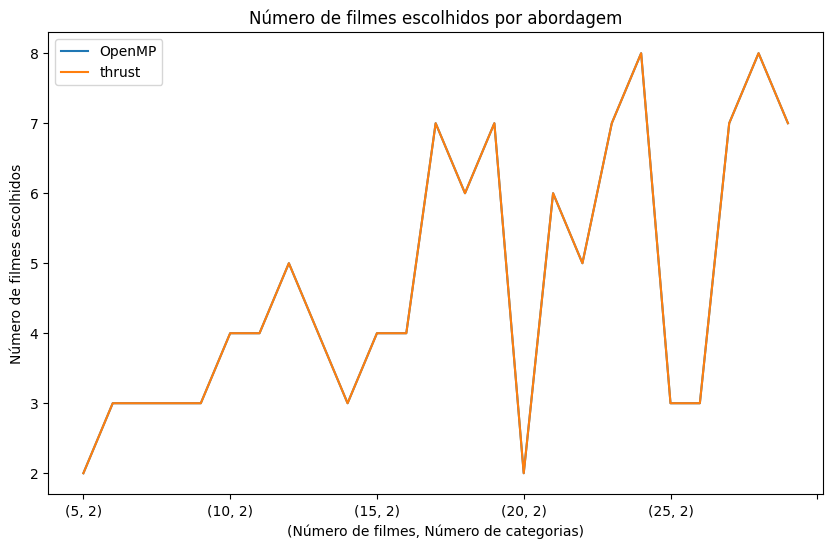

```python
fig, ax = plt.subplots(figsize=(10, 6))

pivot_table["openmp"].plot(ax=ax, label="OpenMP")
pivot_table["thrust"].plot(ax=ax, label="thrust")
ax.set_title("Número de filmes escolhidos por abordagem")
ax.set_xlabel("(Número de filmes, Número de categorias)")
ax.set_ylabel("Número de filmes escolhidos")
ax.legend()

plt.show()
```

```python
# Código para analisar tempo de execução entre algoritmos


df_tempo = df[["abordagem", "num_filmes", "num_categoriar","runtime"]]
df_tempo = df_tempo.sort_values(["num_filmes", "num_categoriar"])
df_tempo.head(10)
```

|  | abordagem | num_filmes | num_categoriar | runtime |
| --- | --- | --- | --- | --- |
| 27 | thrust | 5 | 2 | 0.303820 |
| 28 | openmp | 5 | 2 | 0.103580 |
| 12 | openmp | 5 | 3 | 0.103096 |
| 43 | thrust | 5 | 3 | 0.203708 |
| 6 | thrust | 5 | 4 | 0.307917 |
| 30 | openmp | 5 | 4 | 0.102792 |
| 5 | openmp | 5 | 5 | 0.103419 |
| 32 | thrust | 5 | 5 | 0.203502 |
| 0 | thrust | 5 | 6 | 0.314902 |
| 18 | openmp | 5 | 6 | 0.103799 |

```python
pivot_table = df_tempo.pivot(index=["num_filmes", "num_categoriar"], columns="abordagem", values="runtime")
pivot_table
```

| num_filmes | abordagem num_categoriar | openmp | thrust |
| --- | --- | --- | --- |
| 5 | 2 | 0.103580 | 0.303820 |
|  | 3 | 0.103096 | 0.203708 |
|  | 4 | 0.102792 | 0.307917 |
|  | 5 | 0.103419 | 0.203502 |
|  | 6 | 0.103799 | 0.314902 |
| 10 | 2 | 0.103009 | 0.203372 |
|  | 3 | 0.106766 | 0.304088 |
|  | 4 | 0.102843 | 0.203738 |
|  | 5 | 0.102821 | 0.304630 |
|  | 6 | 0.105348 | 0.203863 |
| 15 | 2 | 0.103633 | 0.304088 |
|  | 3 | 0.104341 | 0.303887 |
|  | 4 | 0.103496 | 0.304089 |
|  | 5 | 0.104937 | 0.203568 |
|  | 6 | 0.104966 | 0.304496 |
| 20 | 2 | 1.005860 | 0.303911 |
|  | 3 | 1.507182 | 0.304246 |
|  | 4 | 1.511713 | 0.303603 |
|  | 5 | 1.412133 | 0.304039 |
|  | 6 | 1.606771 | 0.306627 |
| 25 | 2 | 44.975637 | 1.822217 |
|  | 3 | 44.687127 | 1.612869 |
|  | 4 | 57.003910 | 1.712823 |
|  | 5 | 56.638986 | 1.708437 |
|  | 6 | 57.999938 | 1.813595 |

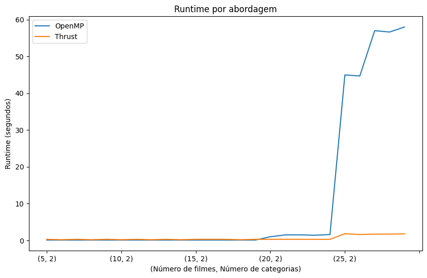

```python
fig, ax = plt.subplots(figsize=(10, 6))

pivot_table["openmp"].plot(ax=ax, label="OpenMP")
pivot_table["thrust"].plot(ax=ax, label="Thrust")
ax.set_title("Runtime por abordagem")
ax.set_xlabel("(Número de filmes, Número de categorias)")
ax.set_ylabel("Runtime (segundos)")
ax.legend()

plt.show()
```

## Análise dos Gráficos

# Conclusão

Continuando o texto da conclusão da primeira parte do projeto, para chegar em uma conclusão final, é necessário definir de antemão o que estamos buscando.

No contexto das heurísticas gulosa e aleatória, podemos considerar diferentes objetivos em relação à quantidade de filmes assistidos e ao tempo de execução.

A heurística gulosa, como o próprio nome sugere, busca tomar decisões imediatas que parecem ser as melhores em cada passo do algoritmo. Ela prioriza a escolha de filmes que maximizam a quantidade assistida em cada momento, sem considerar necessariamente o resultado global ótimo. Portanto, se nosso objetivo principal for maximizar a quantidade de filmes assistidos, a heurística gulosa pode ser uma boa opção. Ela provavelmente resultará em um alto número de filmes assistidos, mas pode não alcançar o resultado ótimo global.

Já a heurística aleatória toma decisões de forma aleatória durante a execução do algoritmo. Ela pode explorar diferentes combinações de filmes escolhidos, o que pode levar a resultados variados. Se o objetivo for obter uma solução rápida sem se preocupar tanto com a quantidade exata de filmes assistidos, a heurística aleatória pode ser adequada. Ela tem a vantagem de ser simples de implementar e pode oferecer uma solução aceitável em termos de tempo de execução.

A próxima e última abordagem é a busca exaustiva que consiste em testar todas as possibilidades de escolha de filmes para encontrar a solução ótima. Porém, nessa abordagem o custo computacional é extremamente grande, principalmente em questão de memória.

Para trabalhar com a busca exaustiva, foram feitas duas implementações, uma com OpenMP e a outra com thrust. Primeiramente, ambas as implementações alcançam o resultado ótimo global em termos do número de filmes assistidos. No entanto, há diferenças significativas em relação ao tempo de execução do código. Ambas as abordagens de paralelização têm o objetivo de aproveitar o poder computacional disponível para reduzir o tempo de execução do algoritmo.

Porém, é importante analisar que mesmo com as paralelizações feitas a busca exaustiva pode ser extremamente inviável para grandes números de filmes, devido a combinação dos filmes crescer exponencialmente. Por conta disso, é necessário encontrar equilíbrio entre a eficiência do algoritmo e a qualidade da solução.